# Question3

Ramzan Kamoto

2024-11-25

## Question3 : Portfolio Construction

The graph below compares the cumulative returns of two indices: an uncapped J203 (in red) and a capped J203 (10%) (in blue). The key distinction between these indices lies in how individual stock weights are handled. In a capped index, no single stock or component is allowed to exceed a predefined weight (10% in this case), whereas the uncapped index has no such restriction. This results in structural differences that explain the divergence in cumulative performance observed in the chart.

Mathematically, the performance of an index can be expressed as:

$$R_t^{Index} = \sum_{i=1}^Nw_i *
R_t^{(i)}$$
Where $R_t^{Index}$ is the return of the index at time t, $w_i$ is the weight of the i-th stock in the index and $R_t^{(i)}$ is the return of the i-th stock at time t. In an uncapped index, $w_i$ can grow indefinitely for high-performing stocks, which means the index benefits more from large, outperforming stocks. Conversely, in a capped index, $w_i$ limited, reducing the contribution of top-performing stocks to the index’s returns.

From the graph, it is evident that the uncapped index outperforms the capped index over time, particularly during periods of market uptrends. This is because uncapped indices capitalize more heavily on the outsized gains of large-cap or high-growth stocks. For example, if a single stock in the uncapped index achieves an exceptional return, its weight grows proportionally, significantly boosting the index’s cumulative return. However, in the capped index, the contribution of such a stock is restricted, which dampens the overall performance. This structural limitation makes capped indices more conservative and less volatile but at the cost of potential upside, as demonstrated by the divergence in returns visible in the graph.

### Visualization

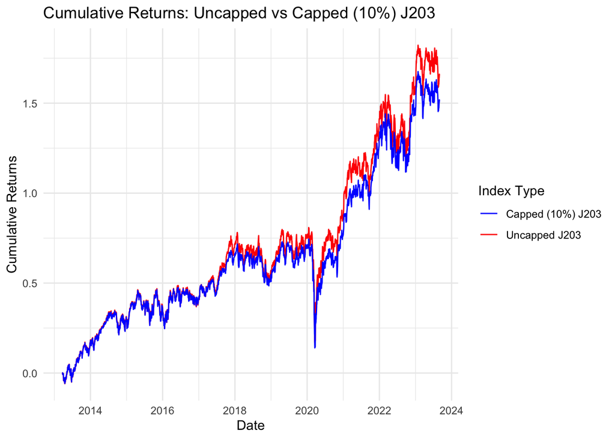